# Algemeines Linear Gemischtes Modell (ALGM)

Das Raschmodell als eine Spezialfall des ALGM

Nicklas Hafiz

2024-08-12

## Überblick

In dieser Session wollen wir uns mit dem Raschmodell als Spezialfall des Allgemeinen Linearen Gemischten Modells (GLMM) beschäftigen. Dafür werden zunächst eine kleine Einführung/Wiederholung zu gemischten Modellen machen und uns dabei spannende Daten anschauen.

Possible example data: Academic motivation scale (https://bookdown.org/bean_jerry/using_r_for_social_work_research/item-response-theory.html)

## GLM

```
tibble [7,185 × 5] (S3: tbl_df/tbl/data.frame)
 $ school  : chr [1:7185] "1224" "1224" "1224" "1224" ...
 $ minority: Factor w/ 2 levels "No","Yes": 1 1 1 1 1 1 1 1 1 1 ...
 $ sex     : Factor w/ 2 levels "Male","Female": 2 2 1 1 1 1 2 1 2 1 ...
 $ ses     : num [1:7185] -1.528 -0.588 -0.528 -0.668 -0.158 ...
 $ mathach : num [1:7185] 5.88 19.71 20.35 8.78 17.9 ...
```

# Gemischte Modelle (Linear Mixed Models)

## Einführungsbeispiel

- Hundedaten nehmen.

# Umgang mit genesteten Daten

Jeweils mit Darstellung, was da gemacht wird.

## Option 1: Ignorieren

Generell eher keine gute Idee:

Wir tun so, als ob wir mehr Informationen hätten, als wir letztendlich haben. Das liegt daran, dass Abhängigkeiten zwischen den Daten bestehen. Konsequenz:

- Standardfehler werden unterschätzt, unsere Inferenzstatistischen Tests werden eher signifikant.

Außerdem kann die genestete Struktur von Interesse sein!

Darstellung: Einfach eine Linie durch den Scatterplot.

## Option 1: Ignorieren

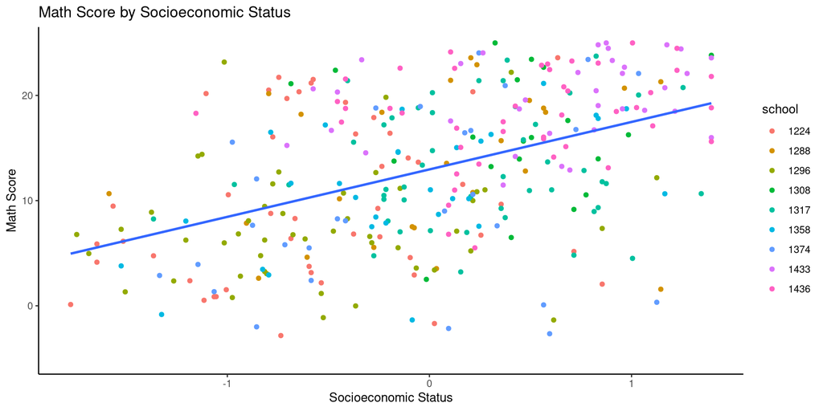

## Option 2: Aggregieren

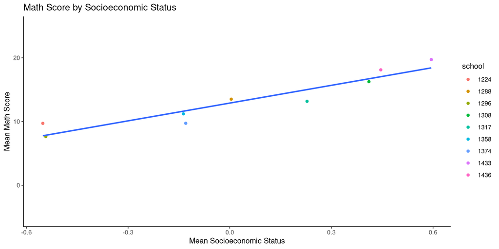

## Option 3: Disaggregiert Analyse mit Gruppen als Prädiktoren

Verstehe noch nicht so ganz, wie das grafisch aussehen würde. https://www.cambridge.org/core/journals/political-science-research-and-methods/article/abs/should-i-use-fixed-or-random-effects/12DFCB222123587A37163F2226E85C67

random effect models reduce bias, but can reduce the variance of estimates of coefficients of interest. some sort of regularization

Wird schnell unübersichtlich, lm z.B. gibt uns viele Infos raus, die uns eigentlich gar nicht interssieren. An sich müsste die Grafik ähnlich aussehen wie im nächsten Beispiel? Die Berechnungen sind aber ein bisscehn anders, v.a. wegen Partial pooling.

## Option 4: Multilevel-Modell

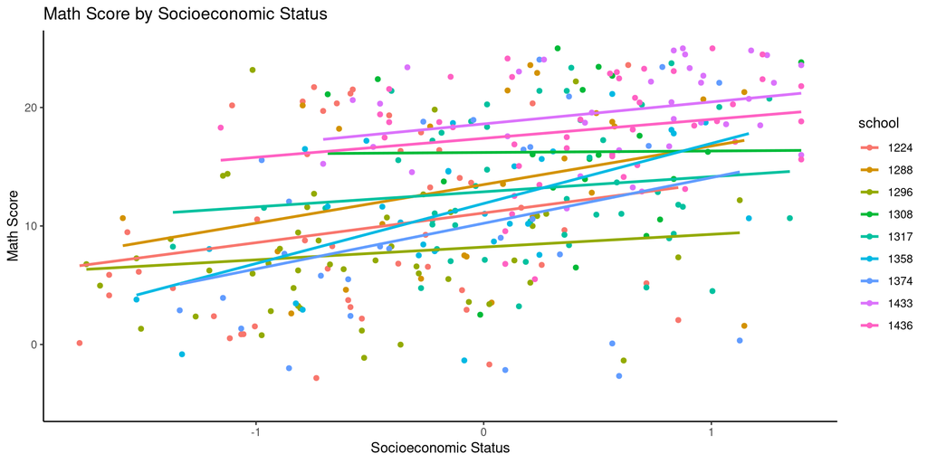

## Notizen

Rein Optisch betrachtet scheint es recht wichtig zu sein, auf welche Schule man geht. Die Abweichung von Mittelwert des GesamtSES hat auch einen Einfluss.

# Gleichungen

## Level 1 Gleichung

Für jede Gruppe j:
$$y_{ij} = \beta_{0j} + \beta_{1j}x_{ij} + e_{ij}$$

## Level-2 Gleichung

$$\beta_{0j} = \beta_{0}+\zeta_{0j}$$

$$\beta_{1j} = \beta_1 + \zeta_{1j}$$

## Das gemischte Modell

Jetzt müssen wir nur noch einsetzen:

$$y_{ij} = \beta_{0j} + \beta_{1j}x_{ij} + e_{ij}$$
$$\beta_{0j} = \beta_{0}+\zeta_{0j}$$

$$\beta_{1j} = \beta_1 + \zeta_{1j}$$

$$y_{ij} = \beta_{0}+\beta_1x_{ij} + \zeta_{0j} + \zeta_{1j}x_{ij} + e_{ij}$$

## Simulation

In der folgenden Übung wollen wir uns Daten mit einer genesteten Struktur simulieren.

https://ademos.people.uic.edu/Chapter16.html

## Was sind random, was fixed effects?

**Random Effects**

- Wir nehmen einen zugrundeliegenden Gesamtmittelwert an, von dem die Gruppen **random** abweichen. Anders ausgedrückt: Wir nehmen an, dass die Gruppen aus einer Grundverteilung gezogen wurden. Wir hätten theoretisch aber auch andere Gruppen ziehen können: Wenn wir das Experiment wiederholen, die level auf diesem Faktor werden andere sein.
- Dann sollten wir partial pooling nutzen:
- Dadurch können wir Informationen aus den Anderen Gruppen ebenfalls nutzen.

**Fixed Effects**

- Hier machen wir diese Annahme einfach nicht. Wir sind also an den tatsächlichen Gruppen interessiert, die wir untersuchen, und möchten nicht davon ausgehen, dass wir theoretisch auch andere Gruppen hätten ziehen können.

## Beispiel

Wir untersuchen den Erfolg von Verhaltenstherapie und Psychoanalyse anhand der Rückfallquote nach einem Jahr.  
Patient*innen müssen hier nach Therapeut*innen genested werden. Dabei können wir die Therapeut*innen als random effects betrachten, wir haben sie ja schließlich nur als Mittel zum Zweck aus der Population an Therapeut*innen gezogen. Die Behandlungsform (Verhaltenstherapie, Psychoanalyse) ist hingegen ein fixed effect, da wir nur diese beiden Behandlungsformen untersuchen wollen.

Anders würde das Ganze aussehen, wenn uns die Erfolgsquote speziell dieser Therapeut*innen interessieren würde. Dann könnten wir sie ebenfalls als fixed effect im Modell mit aufnehmen.

## MML Beispiel mit lme4

- Beispiel von Oben wieder aufnehmen, und auch wieder Ploten was gemacht wurde.
- [Coffe](https://github.com/rfordatascience/tidytuesday/blob/master/data/2024/2024-05-14/readme.md)
- something
- Zur Not die Völkle-Daten aus der VL: https://raffaelevacca.github.io/Intro-multilevel-with-R/
- Simulierte Daten, aber Drachen!: https://ourcodingclub.github.io/tutorials/mixed-models/

# Raschmodell als LMM

Warum das Ganze? Es geht doch eigentlich um IRT?

## Raschmodell als Spezialfall für LMM

Wir können das Raschmodell als Spezialfall des LMMs betrachten:

- De Boeck and Wilson (2004)
- Doran et al. (2007)

## Fixed und Random Effects

- Entwicklung Fragebogen um diesen an verschiedenen Stichproben zu nutzen: Person als random, Items als fixed
- Entwicklung von Items für einen großen Fragenkatalog: Items ebenfalls als random

## Exercise

- Direkt übertragen auf den IRT-KOntext? Also sagen: Nehmt die Daten aus dem letzten Beispiel und fittet ein LLM Modell.
- Dann Vergleich mit TAM.

## Prädiktoren

- Beispiel aufgreifen, zeigen, wass man mit diesen Modell noch machen kann.